# Data Details

**MV104 police reported crash database**

MV104 reports are filled out by NYPD officers responding to a crash. The reports are sent to the state DMV who compiles the data into a database. It is then sent to the state DOT who geocodes the crash location and sends it to NYC DOT.

- Three tables: Crash table, Person table, and Vehicle table, linked by common identifiers.
- NY State DMV has the three tables ([crash](https://data.ny.gov/Transportation/Motor-Vehicle-Crashes-Case-Information-Three-Year-/e8ky-4vqe), [person](https://data.ny.gov/Transportation/Motor-Vehicle-Crashes-Individual-Information-Three/ir4y-sesj), [vehicle](https://data.ny.gov/Transportation/Motor-Vehicle-Crashes-Vehicle-Information-Three-Ye/xe9x-a24f)) on NY Open Data, but does not include the common identifiers needed to link the datasets together.

Before 2017 NYPD used paper reports. In 2017 they switched over to an electronic system called FORMS. This allows them maintain their own database of information instead of having to rely on the state.

[figure not shown]

**Hospital records data**

- Hospital administrative records were obtained from NY SPARCS (Statewide Planning and Research Cooperative System).
- Time period: 2011 - 2013 (Billing code changes prior to 2011 made using earlier data infeasible. Post 2013 hospital data was not available at the time.)
- Injury Severity Score derived from patient records using the Barell matrix formula. (b-ISS).

DOHMH used the hospital administrative data on each patient to determine an injury severity score using the [Barell Matrix method](https://www.ncbi.nlm.nih.gov/pmc/articles/PMC2564435/) . The Barell Matrix is a classification system to translate billing codes into a matrix of injury types. These groupings are given an [Abbreviated Injury Scale (AIS) code](https://en.wikipedia.org/wiki/Abbreviated_Injury_Scale) ranging from 1 to 6 ( from minor injury to death). Patients have an AIS for each injury, these are combined into one overall [Injury Severity Score (ISS)](https://en.wikipedia.org/wiki/Injury_Severity_Score) by taking the top three AIS from different body regions, squaring them and summing.

**Linked Police Reports and Hospital data**

In 2017 DOHMH linked police crash report data with hospital data. [Reference: Conderino, S, Fung, L et al. “Linkage of traffic crash and hospitalization records with limited identifiers for enhanced public health surveillance” AA&P 2017.] About half the hospitalizations and ER visits related to traffic crashes were able to be matched to an MV104 crash report. They used a probabilistic matching method based on person level attributes (age, sex, crash role, collision type, date and time of crash, injury type, injury body location, and county). The time period was 2011 - 2013 (Billing code changes prior to 2011 made using earlier data infeasible. Post 2013 hospital data was not available at the time.)

[figure not shown]

This gave us a valuable dataset to start our analysis. The rest of this notebook explores the data in the linked dataset as well as the larger crash database.

```python
import pandas as pd
pd.options.display.max_rows = 130
pd.options.display.max_columns = 130

import numpy as np

import matplotlib.pyplot as plt
% matplotlib inline
plt.style.use('seaborn-poster')
plt.style.use('ggplot')

import databuild as db
import sys
sys.path.insert(0,'/home/deena/Documents/data_munge/ModaCode/')
import moda
```

```python
# read in DMV data into 3 tables
crash,ind,veh = db.readDMV()

# reorganize into pedestrian/bicyclist 1-veh crashes
ped = db.buildTablesDMV(crash,ind,veh)

#read in DMV-SPARCS linked data
linked = db.readLinked()

# included biss data from linked onto ped (dropping anything not in linked)
ped = db.mergeBiss(ped,linked)

#format and categorize variables
ped = db.formatVars(ped)

print 'linked ped',ped.shape
```

```
full crash table (522108, 26)
full person table (1502797, 22)
full vehicle table (1092922, 20)
```

```
pedestrians/bicyclists (police reported) (single vehicle) (95292, 80)
linked (76763, 131)
linked after dropping no police reports (69657, 131)
linked ped (17624, 106)
```

```python
crash.date.min(),crash.date.max()
```

```
(Timestamp('2007-01-01 00:00:00'), Timestamp('2013-12-31 00:00:00'))
```

```python
# police reported crashes
crashPR = crash[crash.POL_REPT=='Y']
indPR = ind[ind.CS_ID.isin(crashPR.CS_ID)&(~ind.INJT_ID.isin(['16','17','18']))]
crashPR = crashPR[crashPR.CS_ID.isin(indPR.CS_ID)]

print crash.shape
print crashPR.shape
```

```
(522108, 26)
(371958, 26)
```

## Police Reported Crashes - number per day

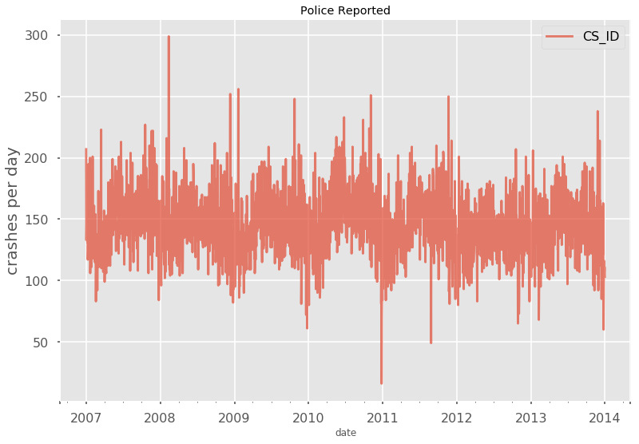

```python
# police reported crashes
crashPR.groupby('date').count()[['CS_ID']].plot(alpha=.7)
plt.ylabel('crashes per day',fontsize=20)
plt.title('Police Reported')
```

## People involved in police reported crashes

- by role
- by injury severity (KABCO)

```python
# format the variables for easier analysis
base = indPR.merge(crash.drop(['RDSYST_ID'],axis=1),
                      how='left',on='CS_ID')
base = db.formatVars(base)
```

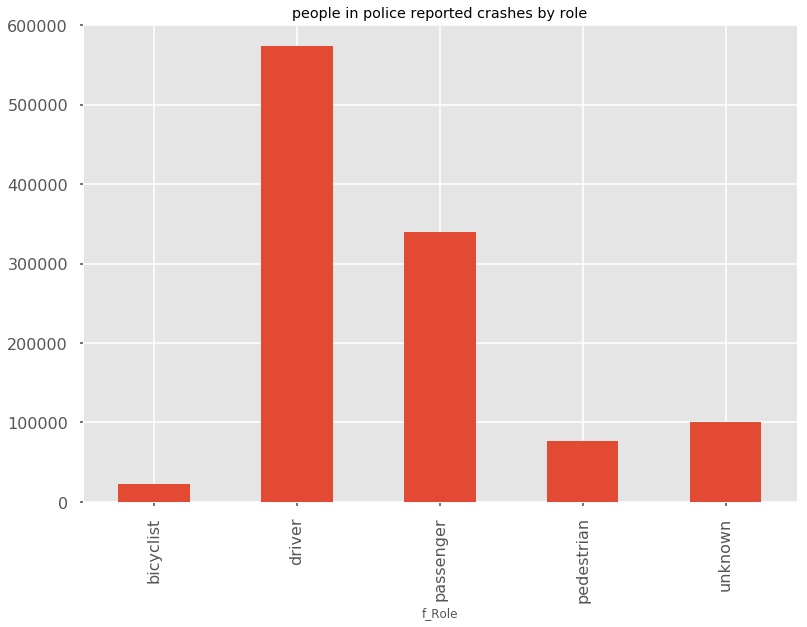

```python
base.groupby(base.f_Role).count()[['CS_ID']].plot(kind='bar',legend=False)
plt.title('people in police reported crashes by role')
```

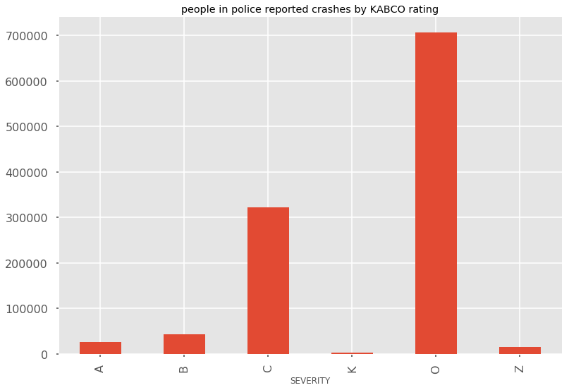

```python
base.groupby(base.SEVERITY).count()[['CS_ID']].plot(kind='bar',legend=False)
plt.title('people in police reported crashes by KABCO rating')
```

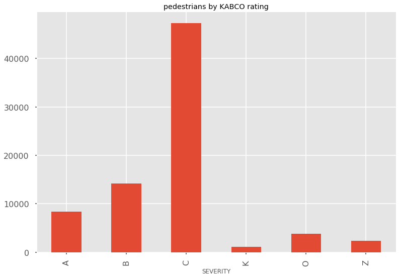

```python
base[base.f_Role=='pedestrian'].groupby(base.SEVERITY).count()[['CS_ID']]\
    .plot(kind='bar',legend=False)
plt.title('pedestrians by KABCO rating')
```

## Fatal or Severely injured (K,A) people

- per day
- per year

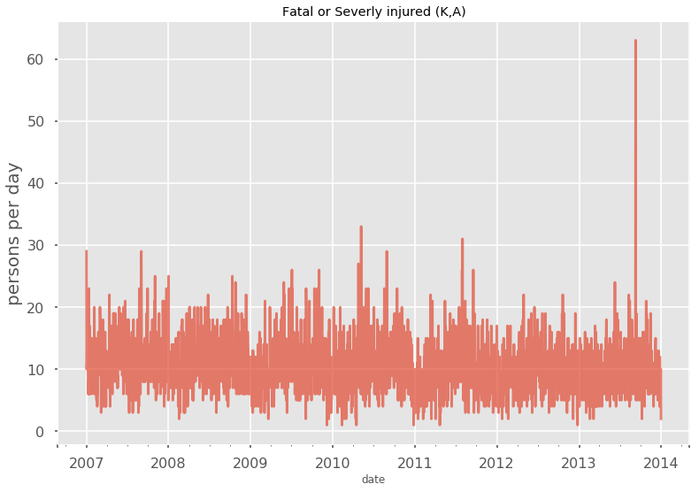

```python
# number of severely injured people per day
sevInjPer = base[base.SEVERITY.isin(['K','A'])]
sevInjPer.groupby('date').count()[['CS_ID']].plot(alpha=.7,legend=False)
plt.ylabel('persons per day',fontsize=20)
plt.title('Fatal or Severly injured (K,A)')
```

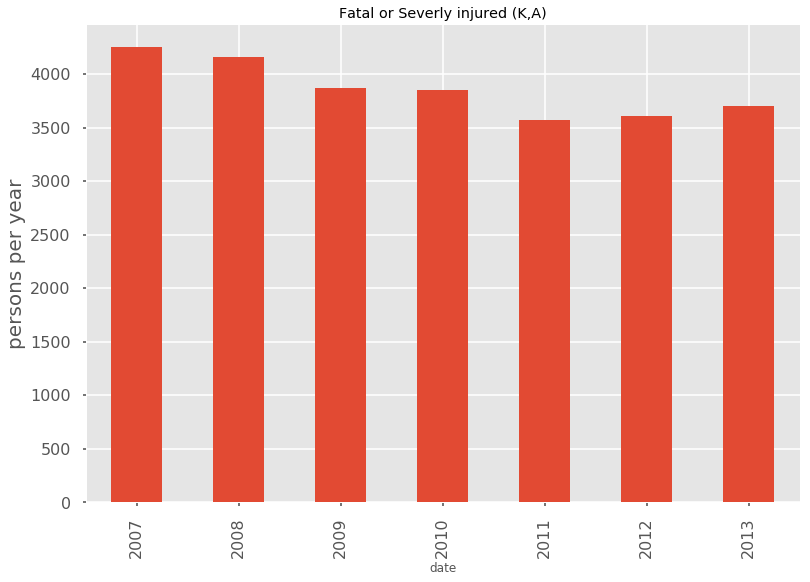

```python
sevInjPer.groupby(sevInjPer.date.dt.year).count()[['CS_ID']].plot(kind='bar',
                                                                  legend=False)
plt.ylabel('persons per year',fontsize=20)
plt.title('Fatal or Severly injured (K,A)')
```

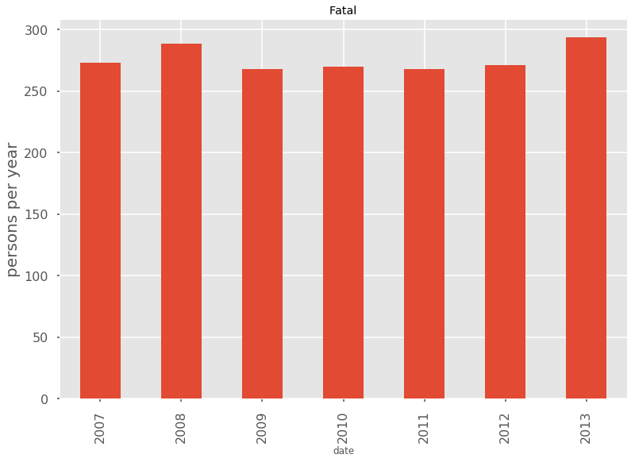

```python
# number of fatalities per day
fatal = base[base.SEVERITY.isin(['K'])]
fatal.groupby(fatal.date.dt.year).count()[['CS_ID']].plot(kind='bar',legend=False)
plt.ylabel('persons per year',fontsize=20)
plt.title('Fatal')
```

## Pedestrians: Fatal or Severely injured (K,A)

- per day
- per year

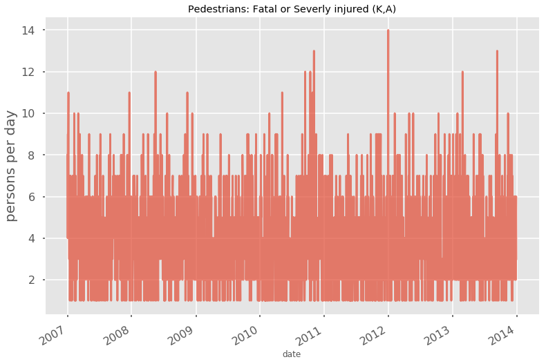

```python
# number of severely injured pedestrians per day
sevInjPed = base[(base.SEVERITY.isin(['K','A']))&(base.f_Role=='pedestrian')]
sevInjPed.groupby('date').count()[['CS_ID']].plot(alpha=.7,legend=False)
plt.ylabel('persons per day',fontsize=20)
plt.title('Pedestrians: Fatal or Severly injured (K,A)')
```

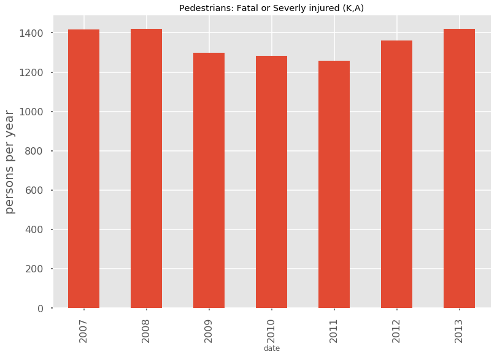

```python
# number of severely injured pedestrians per year
sevInjPed.groupby(sevInjPed.date.dt.year).count()[['CS_ID']].plot(kind='bar',
                                                                 legend=False)
plt.ylabel('persons per year',fontsize=20)
plt.title('Pedestrians: Fatal or Severly injured (K,A)')
```

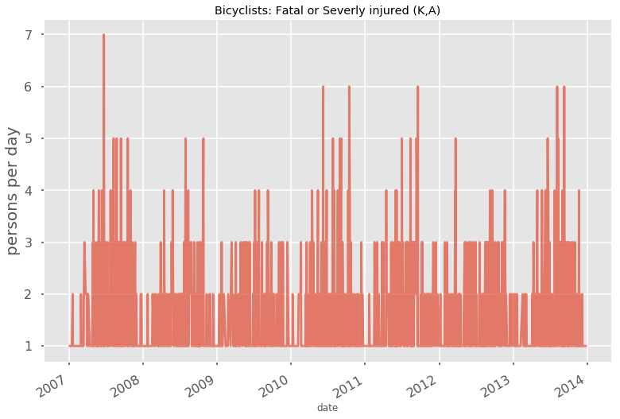

```python
# number of severely injured bicyclists per day
sevInjBic = base[(base.SEVERITY.isin(['K','A']))&(base.f_Role=='bicyclist')]
sevInjBic.groupby('date').count()[['CS_ID']].plot(alpha=.7,legend=False)
plt.ylabel('persons per day',fontsize=20)
plt.title('Bicyclists: Fatal or Severly injured (K,A)')
```

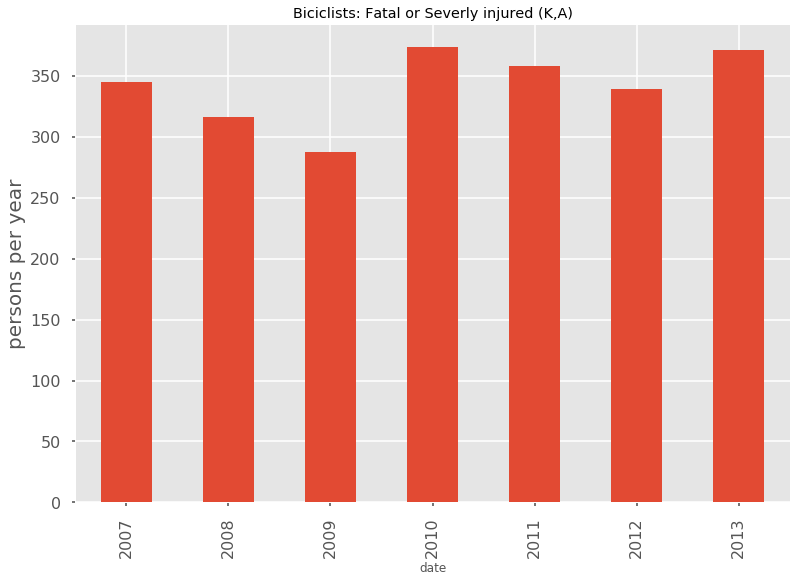

```python
sevInjBic.groupby(sevInjBic.date.dt.year).count()[['CS_ID']].plot(kind='bar',
                                                                  legend=False)
plt.ylabel('persons per year',fontsize=20)
plt.title('Biciclists: Fatal or Severly injured (K,A)')
```

Summary Numbers

```python
print 'crashes per year',crashPR.shape[0]/7
```

```
crashes per year 53136
```

```python
kabcInjury = base[base.SEVERITY.isin(['K','A','B','C'])].CS_ID
print 'people with K, A,B, or C injuries per year',kabcInjury.shape[0]/7
print 'crashes with K, A,B, or C injuries per year',crash[(crash.CS_ID.isin(kabcInjury))].shape[0]/7
```

```
people with K, A,B, or C injuries per year 56071
crashes with K, A,B, or C injuries per year 38959
```

```python
aInjury = base[base.SEVERITY.isin(['A'])].CS_ID
print 'people with A injuries per year',aInjury.shape[0]/7
print 'crashes with A injuries per year',crash[(crash.CS_ID.isin(aInjury))].shape[0]/7
```

```
people with A injuries per year 3581
crashes with A injuries per year 3133
```

```python
kInjury = base[base.SEVERITY.isin(['K'])].CS_ID
print 'fatalities per year',kInjury.shape[0]/7
print 'crashes with fatalities per year',crash[(crash.CS_ID.isin(kInjury))].shape[0]/7
```

```
fatalities per year 276
crashes with fatalities per year 263
```

# Linked police and hospital data

The rest of the notebook is on the linked data. People who were able to be matched from the police report to the hospital records.

```python
print 'number of people in the linked data',linked.shape[0]
```

```
number of people in the linked data 69657
```

```python
print 'number of crashes in the linked data',linked.drop_duplicates('CS_ID').shape[0]
```

```
number of crashes in the linked data 57699
```

```python
event = {
    1:'Other Motor Vehicle, Collision With',
    2:'Pedestrian, Collision With',
    3:'Bicyclist, Collision With'}

linked['event'] = linked.EVNTT_ID.astype(int).map(event)

linked.drop_duplicates('CS_ID').fillna('other object').groupby(['event'])\
    .count()[['CI_ID']]
```

| event | CI_ID |
| --- | --- |
| Bicyclist, Collision With | 3651 |
| Other Motor Vehicle, Collision With | 36622 |
| Pedestrian, Collision With | 14262 |
| other object | 3164 |

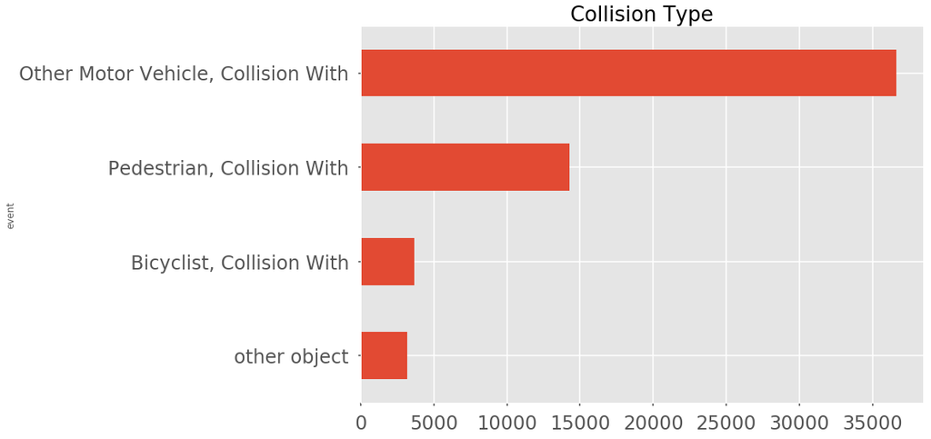

```python
linked.drop_duplicates('CS_ID').fillna('other object').groupby(['event'])\
    .count()[['CI_ID']].sort_values('CI_ID').plot(kind='barh',legend=False,fontsize=24)

plt.title('Collision Type',fontsize=26)
```

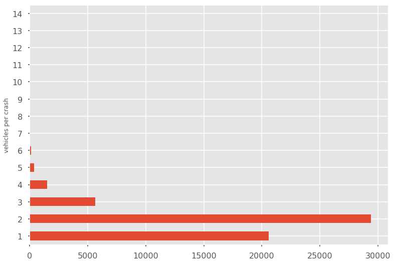

```python
linked.drop_duplicates('CS_ID').groupby(linked.VEH_CNT.astype(int))\
    .count()[['CI_ID']].plot(kind='barh',legend=False)
plt.ylabel('vehicles per crash')
```

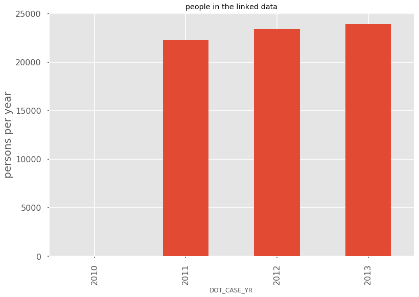

```python
# linked number per year
linked.groupby('DOT_CASE_YR').count()[['CS_ID']].plot(kind='bar',legend=False)
plt.ylabel('persons per year',fontsize=20)
plt.title('people in the linked data')
```

```python
linked.groupby('DOT_CASE_YR').count()[['CS_ID']]
```

| DOT_CASE_YR | CS_ID |
| --- | --- |
| 2010 | 31 |
| 2011 | 22291 |
| 2012 | 23393 |
| 2013 | 23942 |

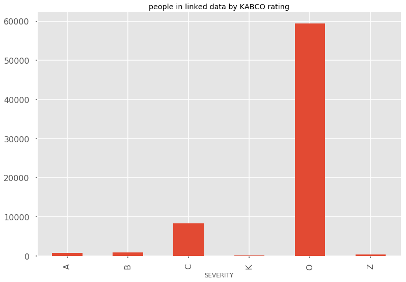

```python
linked.groupby(base.SEVERITY).count()[['CS_ID']].plot(kind='bar',legend=False)
plt.title('people in linked data by KABCO rating')
```

## Pedestrian/bicyclist 1-vehicle - linked data

pedestrians and bicyclists involved in one vehicle collisions in the linked dataset

```python
ped[ped.CI_SEX_CDE_driver=='unknown'].groupby(ped.f_OtherVehTypeVIN).count()[['CI_ID']]
```

| f_OtherVehTypeVIN | CI_ID |
| --- | --- |
| Bus | 1 |
| Car | 340 |
| Minivan | 8 |
| Pickup | 3 |
| SUV | 88 |
| Truck | 4 |
| Van | 35 |
| unknown | 3042 |

```python
ped[ped.CI_SEX_CDE_driver=='unknown'].groupby(ped.f_OtherVehType).count()[['CI_ID']]
```

| f_OtherVehType | CI_ID |
| --- | --- |
| Bus | 20 |
| Car | 598 |
| Motorcycle | 10 |
| Pickup | 11 |
| Suburban | 334 |
| Truck | 24 |
| Van | 64 |
| unknown | 2460 |

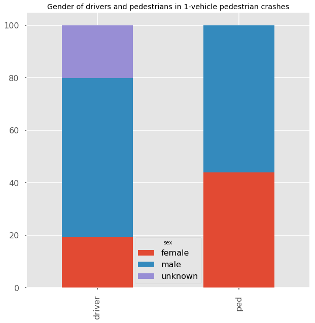

```python
title = 'Gender of drivers and pedestrians in 1-vehicle pedestrian crashes'
pedSexCount = ped.groupby('f_Sex').count()[['CI_ID']]/ped.shape[0]*100
pedSexCount.columns=['ped']
pedSexCount.index.name = 'sex'

driverSexCount = ped.groupby('f_DriverSex').count()[['CI_ID']]/ped.shape[0]*100
driverSexCount.columns = ['driver']
driverSexCount.index.name = 'sex'
driverSexCount.join(pedSexCount).T.plot(kind='bar',
                                        stacked=True,
                                        figsize=(10,10),title=title)
```

```python
driverSexCount.join(pedSexCount)#.T.plot(kind='bar',stacked=True,figsize=(10,6))
```

| sex | driver | ped |
| --- | --- | --- |
| female | 19.428053 | 43.894689 |
| male | 60.485701 | 56.105311 |
| unknown | 20.086246 | NaN |

### Severity

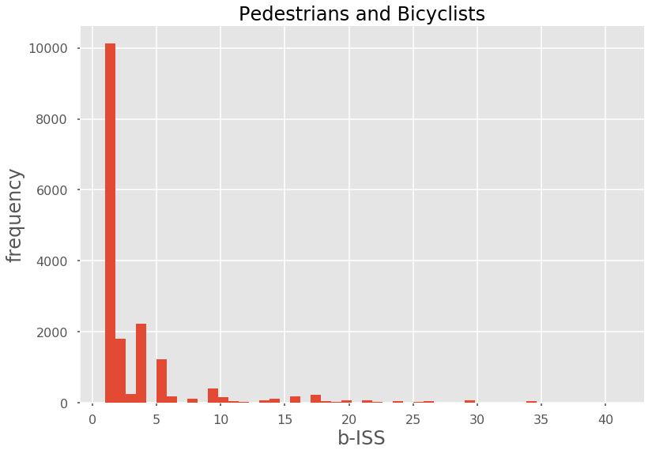

```python
ped.hosp_biss.hist(bins=50)
plt.ylabel('frequency',fontsize=24)
plt.xlabel('b-ISS',fontsize=24)
plt.title('Pedestrians and Bicyclists',fontsize=24)
```

```python
ped.shape
```

```
(17624, 106)
```

counts and percentage of severe

- severe = b-ISS > 8
- severe = b-ISS > 15

```python
ped.groupby(ped.hosp_biss>8).count()[['CI_ID']]
```

| hosp_biss | CI_ID |
| --- | --- |
| False | 15916 |
| True | 1708 |

```python
ped.groupby(ped.hosp_biss>8).count()[['CI_ID']]/ped.shape[0]
```

| hosp_biss | CI_ID |
| --- | --- |
| False | 0.903087 |
| True | 0.096913 |

```python
ped.groupby(ped.hosp_biss>15).count()[['CI_ID']]
```

| hosp_biss | CI_ID |
| --- | --- |
| False | 16725 |
| True | 899 |

```python
ped.groupby(ped.hosp_biss>15).count()[['CI_ID']]/ped.shape[0]
```

| hosp_biss | CI_ID |
| --- | --- |
| False | 0.94899 |
| True | 0.05101 |

KABCO rating vs b-ISS for pedestrian linked

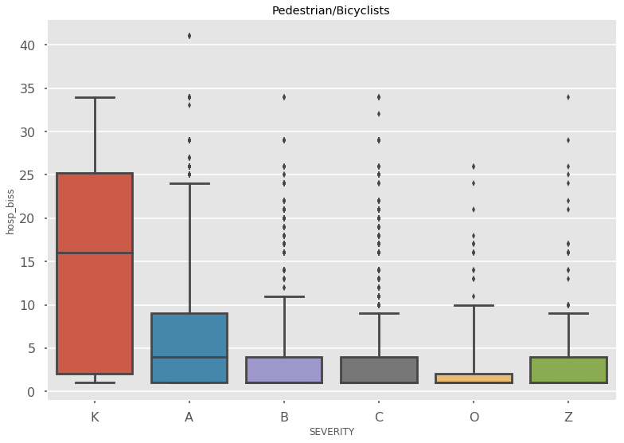

```python
import seaborn as sns

sns.boxplot(x='SEVERITY',y='hosp_biss',
            data=ped,order=['K','A','B','C','O','Z'], whis=[5,95]
           ).set_title('Pedestrian/Bicyclists')
```

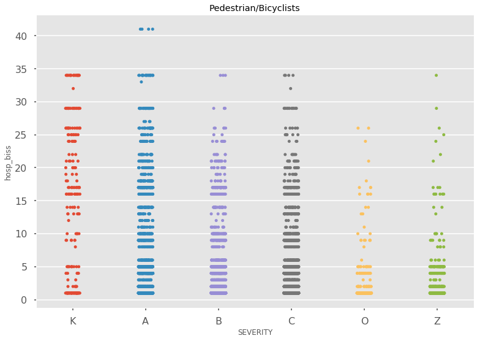

```python
sns.stripplot(x='SEVERITY',y='hosp_biss',
            data=ped,order=['K','A','B','C','O','Z'],jitter=True
           ).set_title('Pedestrian/Bicyclists')
```

```python
ped.groupby('SEVERITY').count()[['CI_ID']]
```

| SEVERITY | CI_ID |
| --- | --- |
| A | 2205 |
| B | 3890 |
| C | 10452 |
| K | 220 |
| O | 326 |
| Z | 531 |

```python
ped['kabco'] = ped[ped.SEVERITY.isin(['B','C','O'])].SEVERITY
ped.loc[ped.SEVERITY.isin(['K','A']),'kabco']='K/A'
ped.groupby('kabco').count()[['CI_ID']]
```

| kabco | CI_ID |
| --- | --- |
| B | 3890 |
| C | 10452 |
| K/A | 2425 |
| O | 326 |

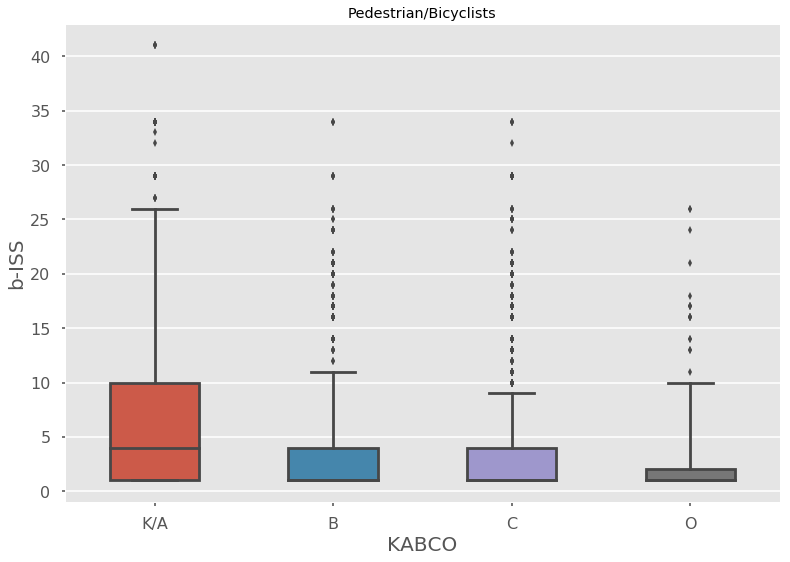

```python
sns.boxplot(x='kabco',y='hosp_biss',
            data=ped,order=['K/A','B','C','O'], whis=[5,95],width=.5
           ).set_title('Pedestrian/Bicyclists')
plt.ylabel('b-ISS',fontsize=20)
plt.xlabel('KABCO',fontsize=20)
```

```python
ped.groupby('kabco').count()[['CI_ID']]
```

| kabco | CI_ID |
| --- | --- |
| B | 3890 |
| C | 10452 |
| K/A | 2425 |
| O | 326 |

```python
ct = pd.crosstab(ped.kabco=='K/A',ped.hosp_biss>8)
ct
```

| hosp_biss kabco | False | True |
| --- | --- | --- |
| False | 14240 | 959 |
| True | 1676 | 749 |

```python
ped.shape[0]
```

```
17624
```